# Data Science Project - Loan Approval

Alex Biuckians, Armin Soroosh, Dania Salman, Kaipu Liu

## Loading the Dataset

```r
# reading dataset
loan_df <- data.frame(read.csv("loan_approval_dataset.csv"))
```

```r
# exploring dataset
str(loan_df)
```

```
## 'data.frame':    4269 obs. of  13 variables:
##  $ loan_id                 : int  1 2 3 4 5 6 7 8 9 10 ...
##  $ no_of_dependents        : int  2 0 3 3 5 0 5 2 0 5 ...
##  $ education               : chr  " Graduate" " Not Graduate" " Graduate" " Graduate" ...
##  $ self_employed           : chr  " No" " Yes" " No" " No" ...
##  $ income_annum            : int  9600000 4100000 9100000 8200000 9800000 4800000 8700000 5700000 800000 1100000 ...
##  $ loan_amount             : int  29900000 12200000 29700000 30700000 24200000 13500000 33000000 15000000 2200000 4300000 ...
##  $ loan_term               : int  12 8 20 8 20 10 4 20 20 10 ...
##  $ cibil_score             : int  778 417 506 467 382 319 678 382 782 388 ...
##  $ residential_assets_value: int  2400000 2700000 7100000 18200000 12400000 6800000 22500000 13200000 1300000 3200000 ...
##  $ commercial_assets_value : int  17600000 2200000 4500000 3300000 8200000 8300000 14800000 5700000 800000 1400000 ...
##  $ luxury_assets_value     : int  22700000 8800000 33300000 23300000 29400000 13700000 29200000 11800000 2800000 3300000 ...
##  $ bank_asset_value        : int  8000000 3300000 12800000 7900000 5000000 5100000 4300000 6000000 600000 1600000 ...
##  $ loan_status             : chr  " Approved" " Rejected" " Rejected" " Rejected" ...
```

The dataset has **4269 observations** with **13 variables**

## Data Cleaning & Summary

### subsetting data and converting categorical variables to factor

Removing loan_id column since it only serves as a unique identifier and does not contribute to the analysis. Furthermore, converting several numeric variables into factors, as they represent categorical information rather than continuous numerical values.

```r
loan_df <- subset(loan_df, select = -c(loan_id))

# converting the numeric variables to factor variables
loan_df$no_of_dependents = as.factor(loan_df$no_of_dependents)
loan_df$education = as.factor(loan_df$education)
loan_df$self_employed = as.factor(loan_df$self_employed)
loan_df$loan_status = as.factor(loan_df$loan_status)
str(loan_df)
```

```
## 'data.frame':    4269 obs. of  12 variables:
##  $ no_of_dependents        : Factor w/ 6 levels "0","1","2","3",..: 3 1 4 4 6 1 6 3 1 6 ...
##  $ education               : Factor w/ 2 levels " Graduate"," Not Graduate": 1 2 1 1 2 1 1 1 1 2 ...
##  $ self_employed           : Factor w/ 2 levels " No"," Yes": 1 2 1 1 2 2 1 2 2 1 ...
##  $ income_annum            : int  9600000 4100000 9100000 8200000 9800000 4800000 8700000 5700000 800000 1100000 ...
##  $ loan_amount             : int  29900000 12200000 29700000 30700000 24200000 13500000 33000000 15000000 2200000 4300000 ...
##  $ loan_term               : int  12 8 20 8 20 10 4 20 20 10 ...
##  $ cibil_score             : int  778 417 506 467 382 319 678 382 782 388 ...
##  $ residential_assets_value: int  2400000 2700000 7100000 18200000 12400000 6800000 22500000 13200000 1300000 3200000 ...
##  $ commercial_assets_value : int  17600000 2200000 4500000 3300000 8200000 8300000 14800000 5700000 800000 1400000 ...
##  $ luxury_assets_value     : int  22700000 8800000 33300000 23300000 29400000 13700000 29200000 11800000 2800000 3300000 ...
##  $ bank_asset_value        : int  8000000 3300000 12800000 7900000 5000000 5100000 4300000 6000000 600000 1600000 ...
##  $ loan_status             : Factor w/ 2 levels " Approved"," Rejected": 1 2 2 2 2 2 1 2 1 2 ...
```

After conversion, the dataset contains four categorical variables:

- **no_of_dependents:** Number of dependents the applicant has (`6` categories: `0`, `1`, `2`, `3`, `4`, `5`)
- **education:** Applicant’s level of education (`2` categories: `Graduate`, `Not Graduate`)
- **self_employed:** Whether the applicant is self-employed (`2` categories: `Yes`, `No`)
- **loan_status:** Loan approval status — this is the target variable (`2` categories: `Approved`, `Rejected`)

### Finding NA values

```r
sum(is.na(loan_df))
```

```
## [1] 0
```

There are no NA values in the data set

### Summary of the dataset

```r
summary(loan_df)
```

```
##  no_of_dependents         education    self_employed  income_annum
##  0:712             Graduate    :2144    No :2119     Min.   : 200000
##  1:697             Not Graduate:2125    Yes:2150     1st Qu.:2700000
##  2:708                                               Median :5100000
##  3:727                                               Mean   :5059124
##  4:752                                               3rd Qu.:7500000
##  5:673                                               Max.   :9900000
##   loan_amount         loan_term     cibil_score  residential_assets_value
##  Min.   :  300000   Min.   : 2.0   Min.   :300   Min.   : -100000
##  1st Qu.: 7700000   1st Qu.: 6.0   1st Qu.:453   1st Qu.: 2200000
##  Median :14500000   Median :10.0   Median :600   Median : 5600000
##  Mean   :15133450   Mean   :10.9   Mean   :600   Mean   : 7472617
##  3rd Qu.:21500000   3rd Qu.:16.0   3rd Qu.:748   3rd Qu.:11300000
##  Max.   :39500000   Max.   :20.0   Max.   :900   Max.   :29100000
##  commercial_assets_value luxury_assets_value bank_asset_value
##  Min.   :       0        Min.   :  300000    Min.   :       0
##  1st Qu.: 1300000        1st Qu.: 7500000    1st Qu.: 2300000
##  Median : 3700000        Median :14600000    Median : 4600000
##  Mean   : 4973155        Mean   :15126306    Mean   : 4976692
##  3rd Qu.: 7600000        3rd Qu.:21700000    3rd Qu.: 7100000
##  Max.   :19400000        Max.   :39200000    Max.   :14700000
##     loan_status
##   Approved:2656
##   Rejected:1613
##
##
##
##
```

### Cleaning up negative values

Checking the number of rows that have negative values for `residential_assets_value` column

```r
sum(loan_df$residential_assets_value < 0)
```

```
## [1] 28
```

There are `28` entries with negative values.

### Removing entries with negative values

```r
loan_df <- loan_df[loan_df$residential_assets_value >= 0, ]
str(loan_df)
```

```
## 'data.frame':    4241 obs. of  12 variables:
##  $ no_of_dependents        : Factor w/ 6 levels "0","1","2","3",..: 3 1 4 4 6 1 6 3 1 6 ...
##  $ education               : Factor w/ 2 levels " Graduate"," Not Graduate": 1 2 1 1 2 1 1 1 1 2 ...
##  $ self_employed           : Factor w/ 2 levels " No"," Yes": 1 2 1 1 2 2 1 2 2 1 ...
##  $ income_annum            : int  9600000 4100000 9100000 8200000 9800000 4800000 8700000 5700000 800000 1100000 ...
##  $ loan_amount             : int  29900000 12200000 29700000 30700000 24200000 13500000 33000000 15000000 2200000 4300000 ...
##  $ loan_term               : int  12 8 20 8 20 10 4 20 20 10 ...
##  $ cibil_score             : int  778 417 506 467 382 319 678 382 782 388 ...
##  $ residential_assets_value: int  2400000 2700000 7100000 18200000 12400000 6800000 22500000 13200000 1300000 3200000 ...
##  $ commercial_assets_value : int  17600000 2200000 4500000 3300000 8200000 8300000 14800000 5700000 800000 1400000 ...
##  $ luxury_assets_value     : int  22700000 8800000 33300000 23300000 29400000 13700000 29200000 11800000 2800000 3300000 ...
##  $ bank_asset_value        : int  8000000 3300000 12800000 7900000 5000000 5100000 4300000 6000000 600000 1600000 ...
##  $ loan_status             : Factor w/ 2 levels " Approved"," Rejected": 1 2 2 2 2 2 1 2 1 2 ...
```

```r
summary(loan_df)
```

```
##  no_of_dependents         education    self_employed  income_annum
##  0:706             Graduate    :2127    No :2106     Min.   : 200000
##  1:696             Not Graduate:2114    Yes:2135     1st Qu.:2700000
##  2:701                                               Median :5100000
##  3:725                                               Mean   :5074251
##  4:744                                               3rd Qu.:7500000
##  5:669                                               Max.   :9900000
##   loan_amount         loan_term     cibil_score  residential_assets_value
##  Min.   :  300000   Min.   : 2.0   Min.   :300   Min.   :       0
##  1st Qu.: 7700000   1st Qu.: 6.0   1st Qu.:453   1st Qu.: 2200000
##  Median :14600000   Median :10.0   Median :600   Median : 5700000
##  Mean   :15178401   Mean   :10.9   Mean   :600   Mean   : 7522613
##  3rd Qu.:21500000   3rd Qu.:16.0   3rd Qu.:747   3rd Qu.:11400000
##  Max.   :39500000   Max.   :20.0   Max.   :900   Max.   :29100000
##  commercial_assets_value luxury_assets_value bank_asset_value
##  Min.   :       0        Min.   :  300000    Min.   :       0
##  1st Qu.: 1300000        1st Qu.: 7500000    1st Qu.: 2400000
##  Median : 3700000        Median :14600000    Median : 4600000
##  Mean   : 4985121        Mean   :15171210    Mean   : 4991488
##  3rd Qu.: 7700000        3rd Qu.:21700000    3rd Qu.: 7100000
##  Max.   :19400000        Max.   :39200000    Max.   :14700000
##     loan_status
##   Approved:2640
##   Rejected:1601
##
##
##
##
```

After filtering out the rows with negative values, the dataset now has `4,241 observations`. The distributions across all variables look almost identical to before, showing that this cleaning step didn’t affect the data overall.

## Exploratory Data Analysis

### Does education level affect loan approval?

```r
library(ggplot2)
edu_table <- table(loan_df$education, loan_df$loan_status)
print(edu_table)
```

```
##
##                  Approved  Rejected
##    Graduate          1329       798
##    Not Graduate      1311       803
```

```r
edu_chi <- chisq.test(edu_table)
print(edu_chi)
```

```
##
##  Pearson's Chi-squared test with Yates' continuity correction
##
## data:  edu_table
## X-squared = 0.08, df = 1, p-value = 0.8
```

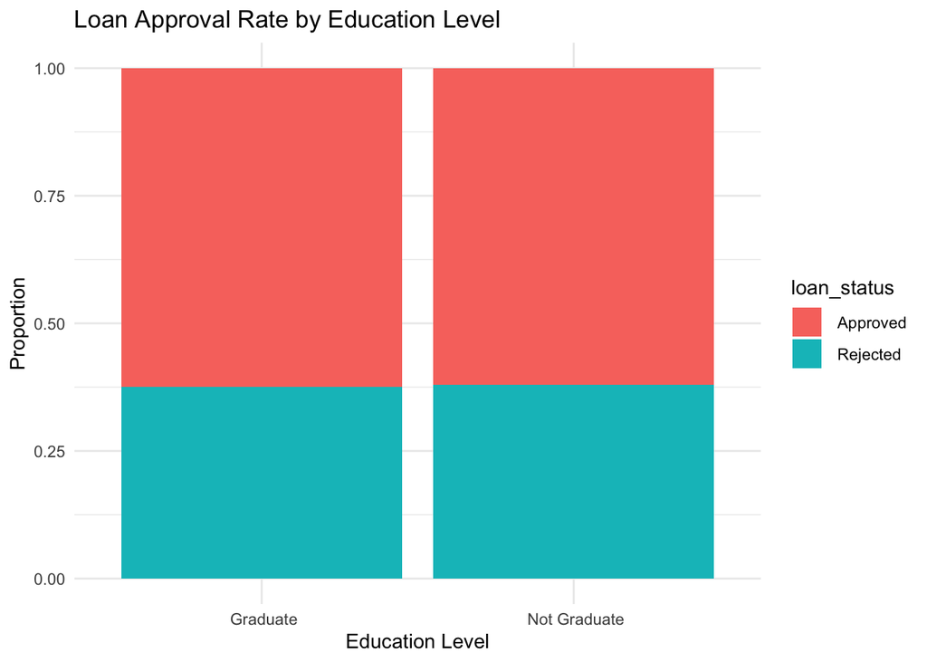

```r
ggplot(loan_df, aes(x = education, fill = loan_status)) +
  geom_bar(position = "fill") +
  labs(title = "Loan Approval Rate by Education Level",
       y = "Proportion",
       x = "Education Level") +
  theme_minimal()
```

Statistical Analysis Breakdown

Chi-Square Test The test statistic is .083958. This indicates that the data is close to what you would expect. The p-value is .772. It is much larger than the standard significance level of .05, we fail to reject the null hypothesis. This is the formal statistical confirmation that there is no significant association between an applicant’s education level and their loan status.

Proportion visualization(The bar chart): The stacked bar chart, which shows the proportion of approvals within each education level, visually confirms the statistical finding. The height of the “Approved” segment is virtually the same for both Graduate and Not Graduate bars, indicating that an individual’s chance of approval is not meaningfully affected by their educational background.

### Do people with higher asset values tend to get approved more often?

```r
# =========================================================
# 2 Do people with higher asset values tend to get approved more often?
# =========================================================
```

```r
#Residential Assets
wilcox.test(residential_assets_value ~ loan_status, data = loan_df)
```

```
##
##  Wilcoxon rank sum test with continuity correction
##
## data:  residential_assets_value by loan_status
## W = 2e+06, p-value = 0.2
## alternative hypothesis: true location shift is not equal to 0
```

```r
# Commercial Assets
wilcox.test(commercial_assets_value ~ loan_status, data = loan_df)
```

```
##
##  Wilcoxon rank sum test with continuity correction
##
## data:  commercial_assets_value by loan_status
## W = 2e+06, p-value = 0.7
## alternative hypothesis: true location shift is not equal to 0
```

```r
# Luxury Assets
wilcox.test(luxury_assets_value ~ loan_status, data = loan_df)
```

```
##
##  Wilcoxon rank sum test with continuity correction
##
## data:  luxury_assets_value by loan_status
## W = 2e+06, p-value = 0.2
## alternative hypothesis: true location shift is not equal to 0
```

```r
# Bank Assets
wilcox.test(bank_asset_value ~ loan_status, data = loan_df)
```

```
##
##  Wilcoxon rank sum test with continuity correction
##
## data:  bank_asset_value by loan_status
## W = 2e+06, p-value = 0.4
## alternative hypothesis: true location shift is not equal to 0
```

The Wilcoxon Rank sum tests is utilized to compared the different asset types between approved and rejected loan applicants. Across the four asset categories, the p-values were greater than .05, indicating that there are no statistically significant differences in asset distributions between loan approval statuses.

```r
shapiro_residential <- shapiro.test(loan_df$residential_assets_value)
shapiro_commercial  <- shapiro.test(loan_df$commercial_assets_value)
shapiro_luxury      <- shapiro.test(loan_df$luxury_assets_value)
shapiro_bank_assets<-shapiro.test(loan_df$bank_asset_value)


cat("p-value (Residential Assets):", shapiro_residential$p.value, "\n")
```

```
## p-value (Residential Assets): 2.04e-46
```

```r
cat("p-value (Commercial Assets):", shapiro_commercial$p.value, "\n")
```

```
## p-value (Commercial Assets): 1.21e-46
```

```r
cat("p-value (Luxury Assets):", shapiro_luxury$p.value, "\n")
```

```
## p-value (Luxury Assets): 1.7e-28
```

```r
cat("p-value (Bank Assets):", shapiro_bank_assets$p.value, "\n")
```

```
## p-value (Bank Assets): 1.11e-32
```

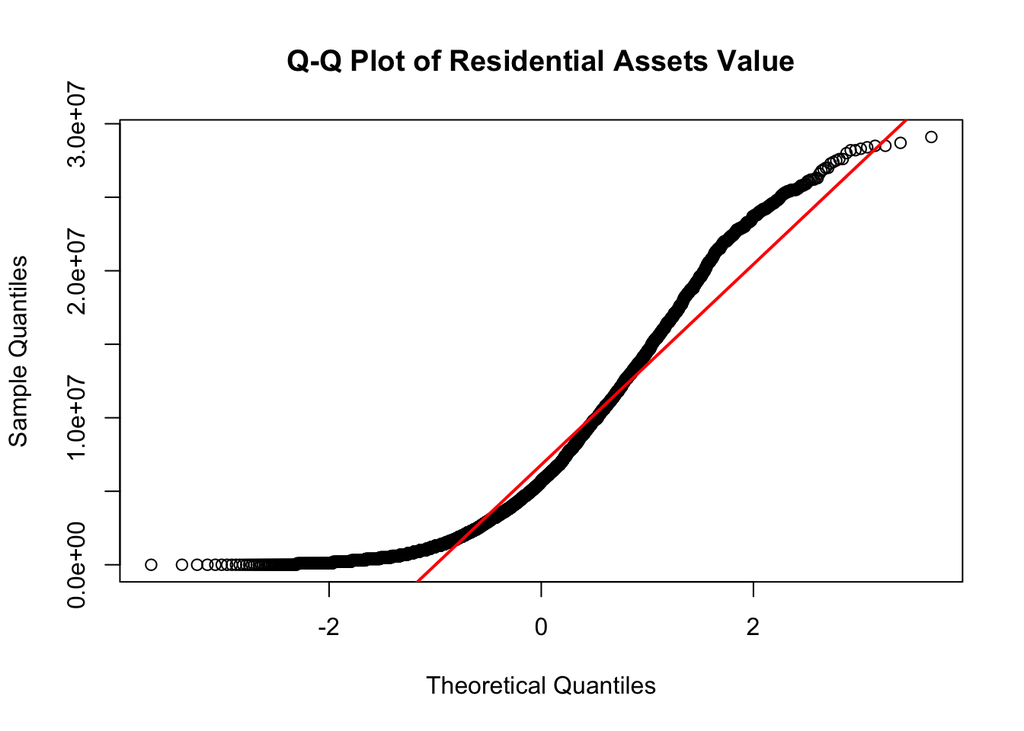

```r
qqnorm(loan_df$residential_assets_value,
       main = "Q-Q Plot of Residential Assets Value")
qqline(loan_df$residential_assets_value, col = "red", lwd = 2)
```

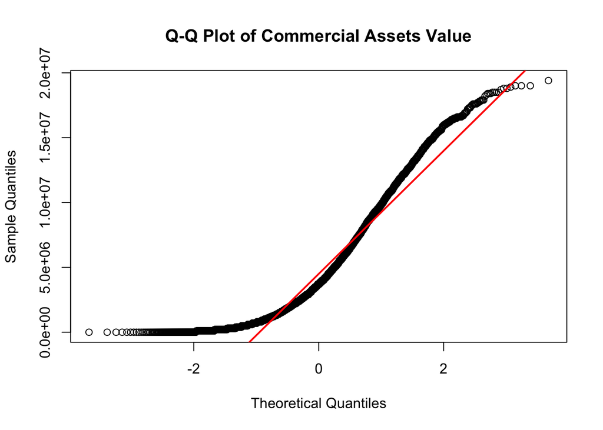

```r
qqnorm(loan_df$commercial_assets_value,
       main = "Q-Q Plot of Commercial Assets Value")
qqline(loan_df$commercial_assets_value, col = "red", lwd = 2)
```

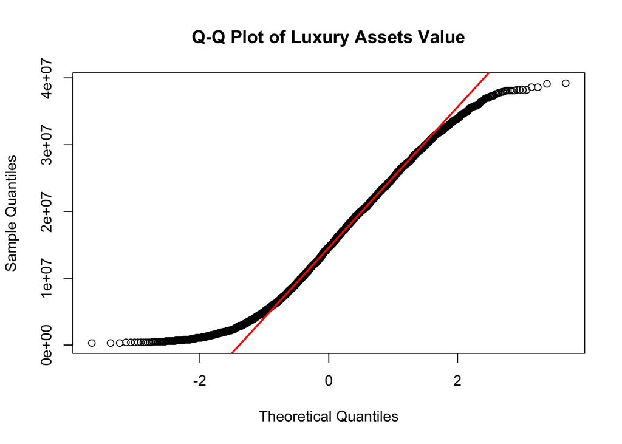

```r
qqnorm(loan_df$luxury_assets_value,
       main = "Q-Q Plot of Luxury Assets Value")
qqline(loan_df$luxury_assets_value, col = "red", lwd = 2)
```

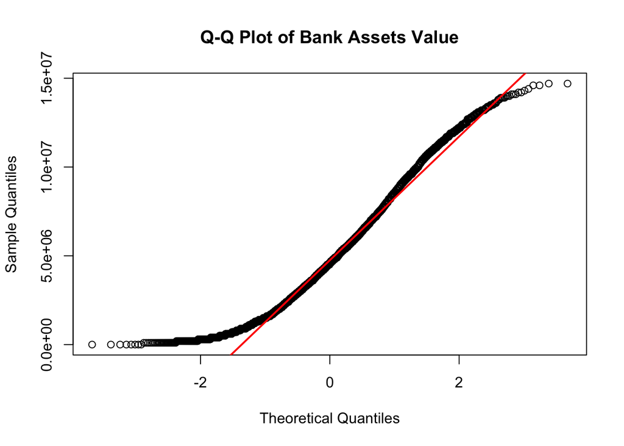

```r
qqnorm(loan_df$bank_asset_value,
       main = "Q-Q Plot of Bank Assets Value")
qqline(loan_df$bank_asset_value, col = "red", lwd = 2)
```

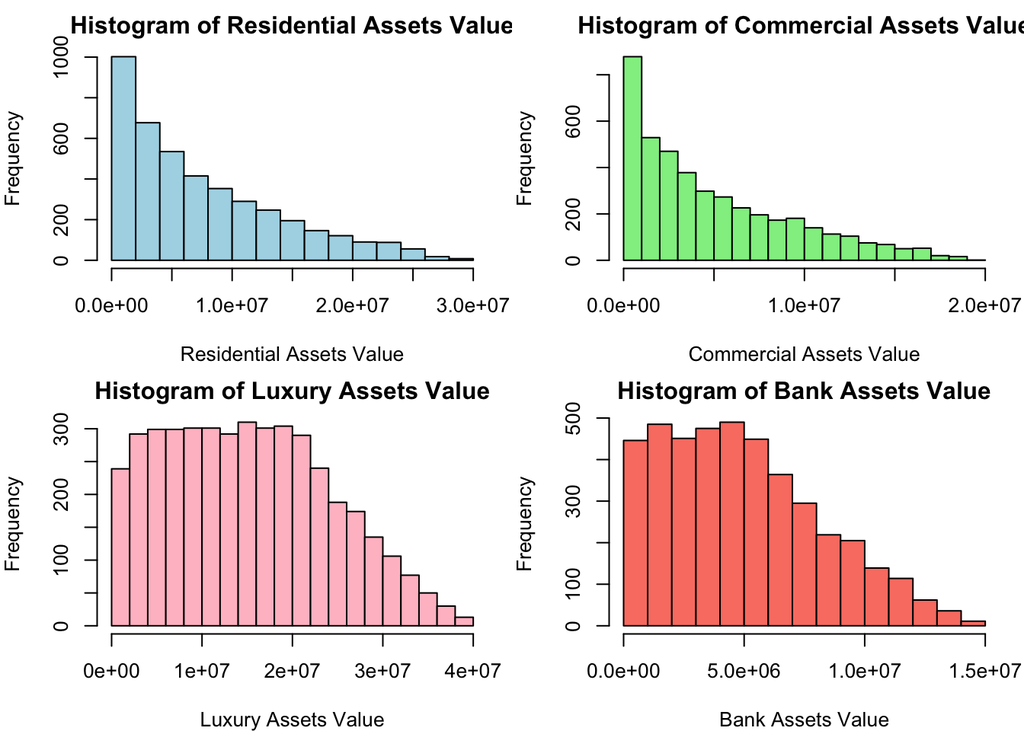

```r
par(mfrow = c(2, 2), mar = c(4, 4, 2, 1))

# 1. Residential Assets Histogram
hist(loan_df$residential_assets_value,
     main = "Histogram of Residential Assets Value",
     xlab = "Residential Assets Value",
     col = "lightblue",
     border = "black")

# 2. Commercial Assets Histogram
hist(loan_df$commercial_assets_value,
     main = "Histogram of Commercial Assets Value",
     xlab = "Commercial Assets Value",
     col = "lightgreen",
     border = "black")

# 3. Luxury Assets Histogram
hist(loan_df$luxury_assets_value,
     main = "Histogram of Luxury Assets Value",
     xlab = "Luxury Assets Value",
     col = "pink",
     border = "black")

# 4. Bank Assets Histogram
hist(loan_df$bank_asset_value,
     main = "Histogram of Bank Assets Value",
     xlab = "Bank Assets Value",
     col = "salmon",
     border = "black")
```

```r
# Reset plotting layout to default (1 plot per screen) after generation
par(mfrow = c(1, 1))
```

### Is there a significant difference in average income between approved and rejected applicants?

```r
# Group by loan approval status and extract their annual income data
approved_income <- loan_df$income_annum[loan_df$loan_status == " Approved"]
rejected_income <- loan_df$income_annum[loan_df$loan_status == " Rejected"]
# Calculate each group's mean annual income
mean_approved <- mean(approved_income, na.rm = TRUE)
mean_rejected <- mean(rejected_income, na.rm = TRUE)
cat("Mean annual income of Approved group:", mean_approved, "\n")
```

```
## Mean annual income of Approved group: 5034886
```

```r
cat("Mean annual income of Rejected group:", mean_rejected, "\n")
```

```
## Mean annual income of Rejected group: 5139163
```

```r
# Conduct hypothesis testing
t_test_result <- t.test(approved_income, rejected_income)
print("t-test result：")
```

```
## [1] "t-test result："
```

```r
print(t_test_result)
```

```
##
##  Welch Two Sample t-test
##
## data:  approved_income and rejected_income
## t = -1, df = 3435, p-value = 0.2
## alternative hypothesis: true difference in means is not equal to 0
## 95 percent confidence interval:
##  -277421   68867
## sample estimates:
## mean of x mean of y
##   5034886   5139163
```

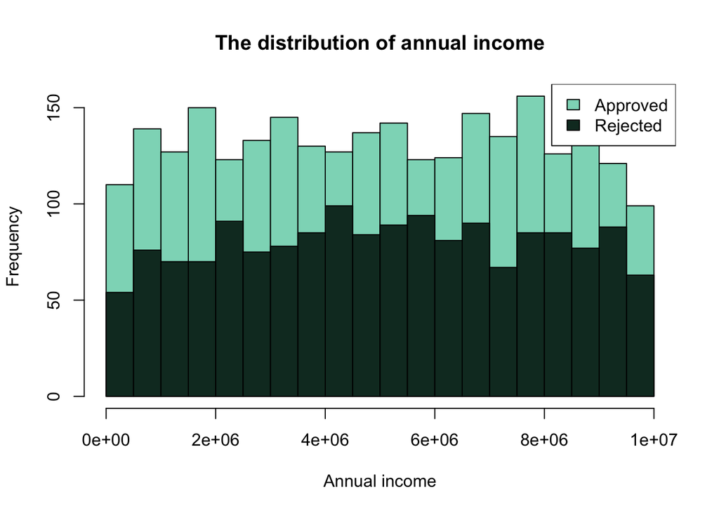

```r
# Draw the histogram
hist(approved_income,
     col = "#8DD9C1",
     main = "The distribution of annual income",
     xlab = "Annual income",
     ylab = "Frequency",
     breaks = 30)
hist(rejected_income,
     col = "#12362A",
     breaks = 30,
     add = TRUE)
legend("topright",
       legend = c("Approved", "Rejected"),
       fill = c("#8DD9C1", "#12362A"))
```

- **Null Hypothesis (H₀):** There is no significant difference in the average annual income between approved and rejected applicants.
- **Alternative Hypothesis (H₁):** There is a significant difference in the average annual income between approved and rejected applicants.

A histogram comparing the income distributions of both groups also shows similar shapes, reinforcing that there is no clear distinction between them.

In conclusion, income alone does not appear to be a strong predictor of loan approval in this dataset.

### Is there a correlation between applicant’s annual income and loan amount requested?

```r
annual_income <- loan_df$income_annum
loan_amount <- loan_df$loan_amount

# Check whether normal distribution
shapiro_income <- shapiro.test(annual_income)
shapiro_loan <- shapiro.test(loan_amount)
cat("p-value of annual income：", shapiro_income$p.value, "\n")
```

```
## p-value of annual income： 7.7e-34
```

```r
cat("p-value of loan amount：", shapiro_loan$p.value, "\n")
```

```
## p-value of loan amount： 6.22e-28
```

```r
# Choose the correlation coefficient
if (shapiro_income$p.value > 0.05 & shapiro_loan$p.value > 0.05) {
  cor_result <- cor.test(annual_income, loan_amount, method = "pearson")
  cat("Pearson result：\n")
} else {
  cor_result <- cor.test(annual_income, loan_amount, method = "spearman")
  cat("Spearman reslut：\n")
}
```

```
## Spearman reslut：
```

```r
print(cor_result)
```

```
##
##  Spearman's rank correlation rho
##
## data:  annual_income and loan_amount
## S = 8e+08, p-value <2e-16
## alternative hypothesis: true rho is not equal to 0
## sample estimates:
##   rho
## 0.941
```

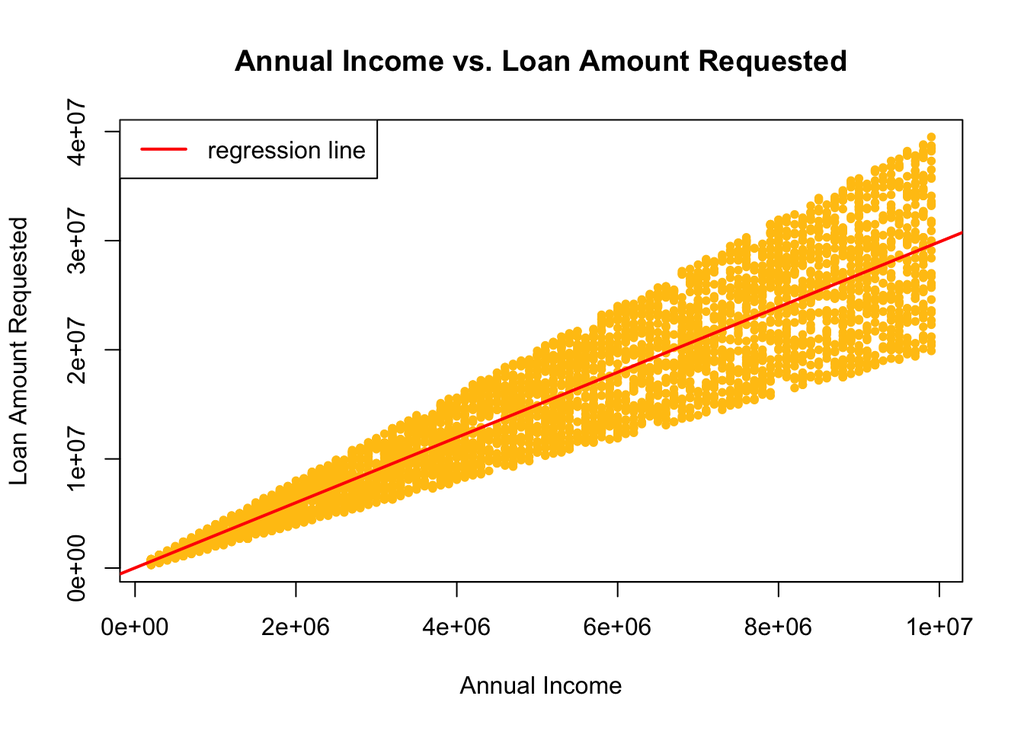

```r
# Draw the plot
plot(
  x = annual_income,
  y = loan_amount,
  main = "Annual Income vs. Loan Amount Requested",
  xlab = "Annual Income",
  ylab = "Loan Amount Requested",
  pch = 16,
  col = "#FFC412",
  cex = 0.8
)
# Add the regression line
abline(lm(loan_amount ~ annual_income), col = "red", lwd = 2)
legend("topleft",
       legend = "regression line",
       col = "red",
       lty = 1,
       lwd = 2)
```

The normality of the data for both annual income and loan amount was tested, and since they did not follow a normal distribution, the Spearman correlation coefficient was used. The resulting `rho = 0.941` indicates a very strong positive correlation between the two variables, with a `p-value < 0.05`, confirming that the relationship is statistically significant.

The scatter plot further supports this finding, showing a clear upward trend—loan amounts increase as annual income increases. The red regression line visually emphasizes this strong positive relationship.

In conclusion, Annual income is a key factor influencing the loan amount requested, as the two are strongly and positively correlated.

### Is there a significant difference in average CIBIL scores between approved and rejected applicants?

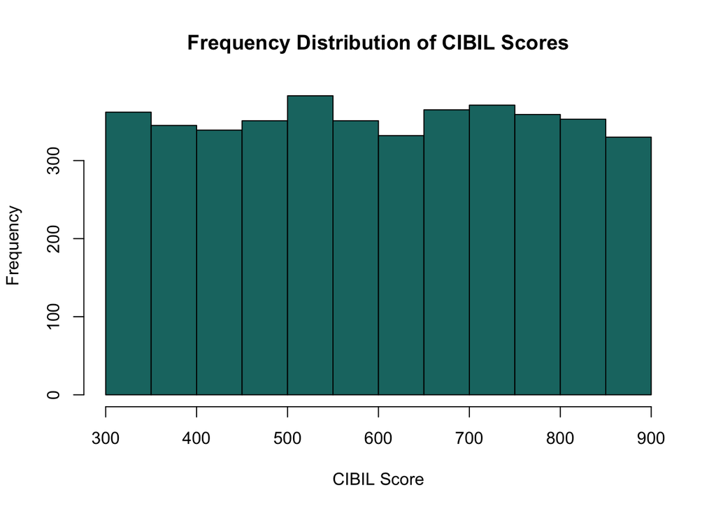

```r
library(ggplot2)
#CIBIL score frequency distribution
hist(loan_df$cibil_score, main = "Frequency Distribution of CIBIL Scores", xlab = "CIBIL Score", ylab = "Frequency", breaks = 15, col = "#197571")
```

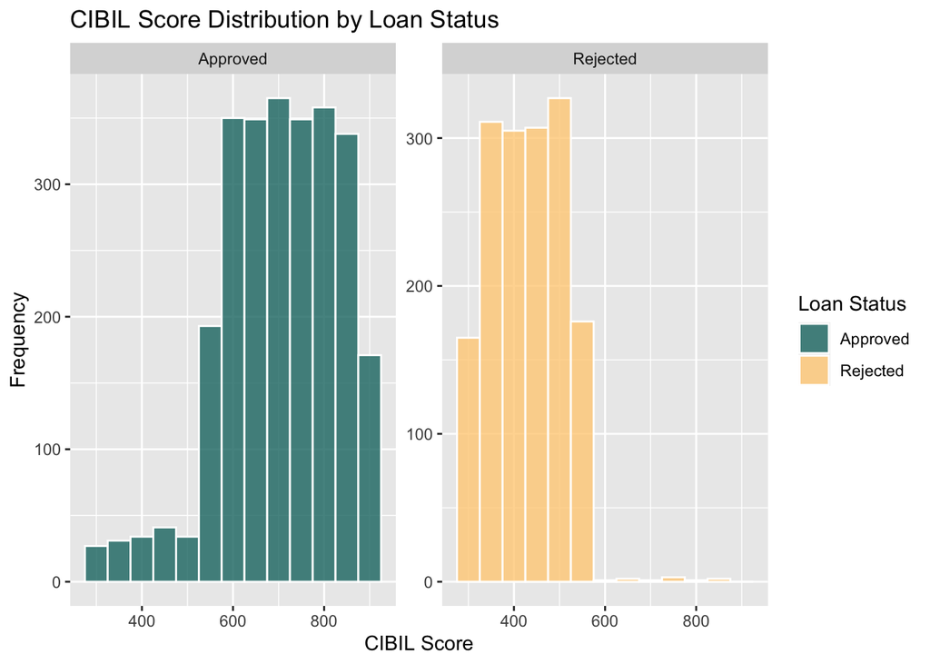

```r
#CIBIL score frequency distribution
loan_df$loan_status <- factor(trimws(loan_df$loan_status))
ggplot(loan_df, aes(x = cibil_score, fill = loan_status)) +
  geom_histogram(binwidth = 50, color = "white", alpha = 0.8) +
  facet_wrap(~ loan_status, scales = "free_y") +
  labs(title = "CIBIL Score Distribution by Loan Status", x = "CIBIL Score", y = "Frequency", fill = "Loan Status") + scale_fill_manual(values = c("Approved" = "#197571", "Rejected" = "#FFCF85"))
```

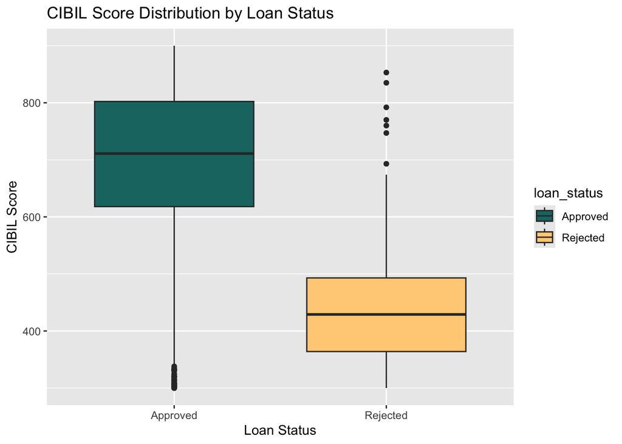

```r
#CIBIL score frequency box chart
ggplot(loan_df, aes(x = loan_status, y = cibil_score, fill = loan_status)) +
  geom_boxplot() +
  labs(title = "CIBIL Score Distribution by Loan Status", x = "Loan Status", y = "CIBIL Score") +
  scale_fill_manual(values = c("Approved" = "#197571", "Rejected" = "#FFCF85"))
```

```r
#t-test
t.test(cibil_score ~ loan_status, data = loan_df)
```

```
##
##  Welch Two Sample t-test
##
## data:  cibil_score by loan_status
## t = 88, df = 4238, p-value <2e-16
## alternative hypothesis: true difference in means between group Approved and group Rejected is not equal to 0
## 95 percent confidence interval:
##  268 280
## sample estimates:
## mean in group Approved mean in group Rejected
##                    703                    429
```

The overall CIBIL score frequency distribution shows no apparent outliers. The individual distributions for approved and rejected loans show a few outliers, but it is not necessary to remove them. Even though the outliers are dragging the two means closer to each other, the means are still significantly different even when including them in the t-test.

There is a significant difference in CIBIL scores between approved and rejected applicants because the p-value, `2e-16`, is much lower than the standard alpha threshold of `0.05`. This allows us to reject the null hypothesis that the two means of approved and rejected applicants are **equal**.

### For rejected loans, is there a significant difference in the mean CIBIL score between applicants with shorter loan term loans (<=10 years) versus longer term loans(>10 years)?

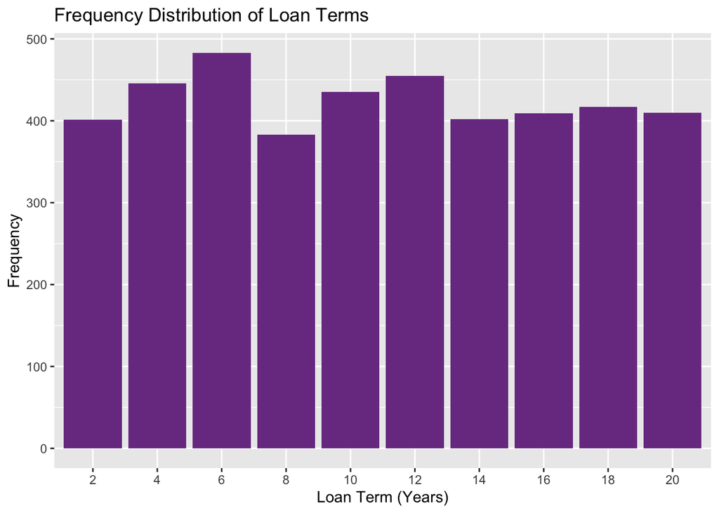

```r
#created subsets for shorter and longer loans then ran t-test
rejected_shorter <- subset(loan_df, trimws(loan_status) == "Rejected" & loan_term <= 10)
rejected_longer <- subset(loan_df, trimws(loan_status) == "Rejected" & loan_term > 10)

#Overall loan term frequency distribution
ggplot(loan_df, aes(x = factor(loan_term))) + geom_bar(fill = "#7B3D91") + labs(title = "Frequency Distribution of Loan Terms", x = "Loan Term (Years)", y = "Frequency")
```

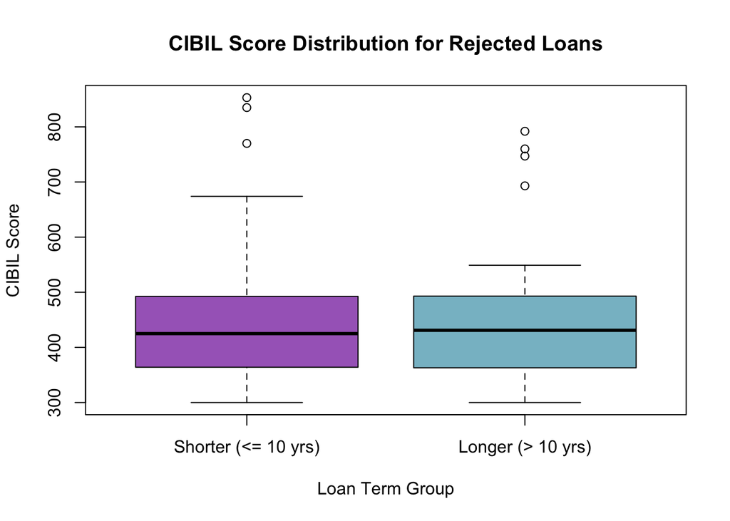

```r
#boxplot
boxplot(
  rejected_shorter$cibil_score,
  rejected_longer$cibil_score,
  names = c("Shorter (<= 10 yrs)", "Longer (> 10 yrs)"),
  main = "CIBIL Score Distribution for Rejected Loans",
  ylab = "CIBIL Score",
  xlab = "Loan Term Group",
  col = c("#A769C2", "#87BDCC")  # add your custom colors here
)
```

```r
#removing outliers
removeOutliers <- function(x) {Q1 <- quantile(x, 0.25)
Q3 <- quantile(x, 0.75);
IQR_val <- Q3 - Q1;
lower_bound <- Q1 - (1.5 * IQR_val);
upper_bound <- Q3 + (1.5 * IQR_val);

return(x[x >= lower_bound & x <= upper_bound]);}

cleaned_shorter_cibil <- removeOutliers(rejected_shorter$cibil_score)
cleaned_longer_cibil <- removeOutliers(rejected_longer$cibil_score)

t.test(rejected_shorter$cibil_score, rejected_longer$cibil_score)
```

```
##
##  Welch Two Sample t-test
##
## data:  rejected_shorter$cibil_score and rejected_longer$cibil_score
## t = -0.03, df = 1564, p-value = 1
## alternative hypothesis: true difference in means is not equal to 0
## 95 percent confidence interval:
##  -7.72  7.51
## sample estimates:
## mean of x mean of y
##       429       429
```

```r
t.test(cleaned_shorter_cibil, cleaned_longer_cibil)
```

```
##
##  Welch Two Sample t-test
##
## data:  cleaned_shorter_cibil and cleaned_longer_cibil
## t = -0.05, df = 1563, p-value = 1
## alternative hypothesis: true difference in means is not equal to 0
## 95 percent confidence interval:
##  -7.47  7.09
## sample estimates:
## mean of x mean of y
##       427       428
```

The overall loan terms frequency distribution shows no apparent outliers however there are a few in the shorter and longer loan term groups. Having this said, even when removing these outliers there no significant differences found between the two groups and their respective CIBIL scores.

There is not a significant difference in CIBIL scores between shorter `(<= 10 years)` and longer `(>10 years)` term loans within the rejected group of applicants because the **p-value**, `1`, is much higher than the standard alpha threshold of `0.05`. This allows us to accept the null hypothesis that the two means of shorter and longer term loans of rejected applicants are equal.

### Is there a correlation between the CIBIL Score and the Loan Term among those whose loans are approved?

```r
#correlation coefficient
corr_r <- cor(loan_df[trimws(loan_df$loan_status) == "Approved", "cibil_score"], loan_df[trimws(loan_df$loan_status) == "Approved", "loan_term"], method = "pearson")

#correlation test
cor.test(loan_df[trimws(loan_df$loan_status) == "Approved", "cibil_score"], loan_df[trimws(loan_df$loan_status) == "Approved", "loan_term"], method = "pearson")
```

```
##
##  Pearson's product-moment correlation
##
## data:  loan_df[trimws(loan_df$loan_status) == "Approved", "cibil_score"] and loan_df[trimws(loan_df$loan_status) == "Approved", "loan_term"]
## t = 11, df = 2638, p-value <2e-16
## alternative hypothesis: true correlation is not equal to 0
## 95 percent confidence interval:
##  0.173 0.246
## sample estimates:
##  cor
## 0.21
```

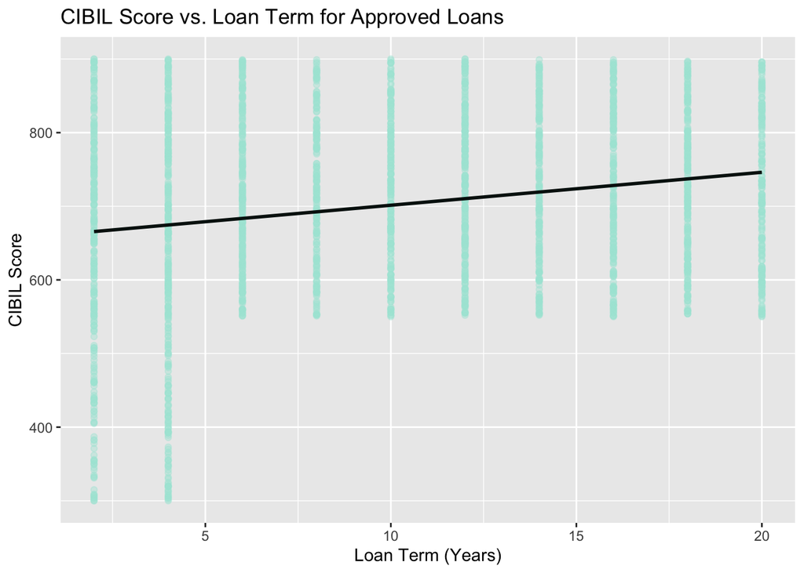

```r
#scatter plot
ggplot(subset(loan_df, trimws(loan_status) == "Approved"), aes(x = loan_term, y = cibil_score)) + geom_point(alpha = 0.4, color = "#AAE5D8") + geom_smooth(method = "lm", se = FALSE, color = "#061411") + labs(title = "CIBIL Score vs. Loan Term for Approved Loans", x = "Loan Term (Years)", y = "CIBIL Score")
```

The correlation coefficient of `0.21` shows a weak but positive relationship where approved candidates with higher CIBIL scores have a slightly higher tendency to approved for longer loan terms. And the p-value is very small, `2e-16`, meaning that the correlation coefficient is unlikely due to chance.

### Does self-employment status affect loan approval?

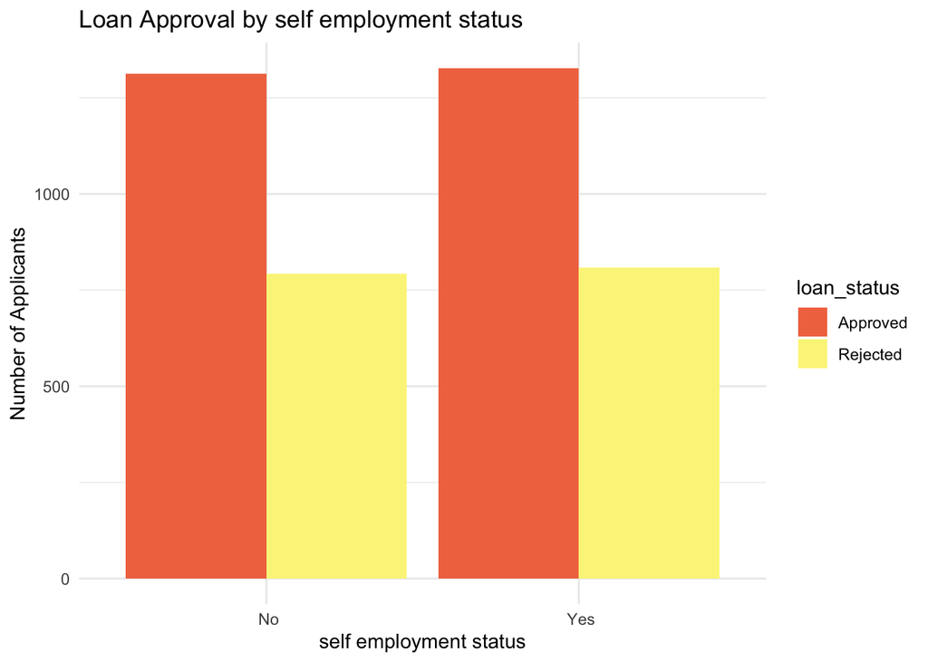

```r
ggplot(loan_df, aes(x = self_employed, fill = loan_status)) +
  geom_bar(position = "dodge") +
  labs(
    title = "Loan Approval by self employment status",
    x = "self employment status",
    y = "Number of Applicants"
  ) +
  scale_fill_manual(values = c("Approved" = "#F2764E", Rejected = "#FAF487")) +
  theme_minimal()
```

Approval rates are nearly **identical** for self-employed and non self-employed applicants, suggesting self-employment likely doesn’t affect loan approval. A Chi-square test will confirm this statistically.

```r
contable <- table(loan_df$self_employed, loan_df$loan_status)
chisq.test(contable)
```

```
##
##  Pearson's Chi-squared test with Yates' continuity correction
##
## data:  contable
## X-squared = 0.009, df = 1, p-value = 0.9
```

### Does the number of dependents affect approval of loans?

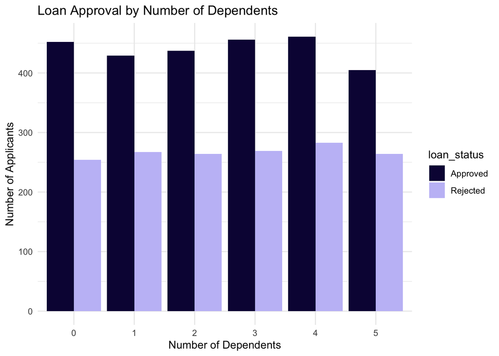

```r
ggplot(loan_df, aes(x = no_of_dependents, fill = loan_status)) +
  geom_bar(position = "dodge") +
  labs(
    title = "Loan Approval by Number of Dependents",
    x = "Number of Dependents",
    y = "Number of Applicants"
  ) +
  scale_fill_manual(values = c("Approved" = "#0D0942", "Rejected" = "#C4C0F6")) +
  theme_minimal()
```

The bar chart shows that approval and rejection counts are fairly similar across all dependent categories, with no noticeable trend suggesting that the number of dependents strongly influences loan approval outcomes. While minor variations exist, the approval rate appears consistent across groups, indicating that loan approval is likely independent of the number of dependents. A Chi-square test will confirm this statistically.

```r
contable <- table(loan_df$no_of_dependents, loan_df$loan_status)
chisq.test(contable)
```

```
##
##  Pearson's Chi-squared test
##
## data:  contable
## X-squared = 2, df = 5, p-value = 0.8
```

The Chi-square test (`p = 0.8`) also shows no significant association between no_of_dependents and loan approval. This confirms that no_of_dependents does not affect the likelihood of loan approval in this dataset.

### Does requested loan term affect approval?

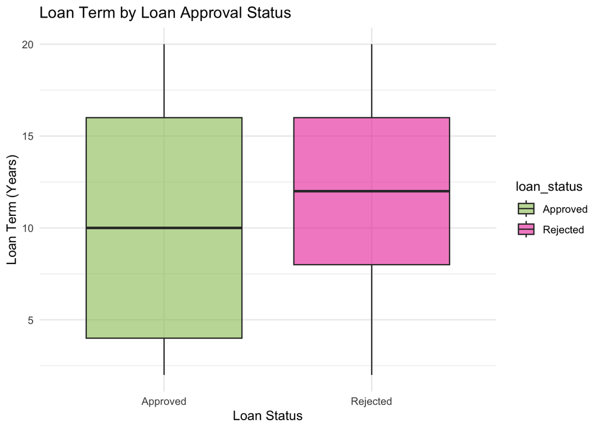

```r
ggplot(loan_df, aes(x = loan_status, y = loan_term, fill = loan_status)) +
  geom_boxplot(alpha = 0.6) +
  labs(
    title = "Loan Term by Loan Approval Status",
    x = "Loan Status",
    y = "Loan Term (Years)"
  ) +
  scale_fill_manual(values = c("Approved" = "#98C25F", "Rejected" = "#EB3BA7")) +
  theme_minimal()
```

The boxplot shows that approved loans have a **wider range** of terms, including very short loans, while rejected loans generally have longer terms. The median loan term for approved loans is `10 years`, compared to `12 years` for rejected loans, indicating that rejected loans tend to have slightly longer terms

```r
t.test(loan_term ~ loan_status, data = loan_df)
```

```
##
##  Welch Two Sample t-test
##
## data:  loan_term by loan_status
## t = -8, df = 3637, p-value = 2e-14
## alternative hypothesis: true difference in means between group Approved and group Rejected is not equal to 0
## 95 percent confidence interval:
##  -1.69 -1.01
## sample estimates:
## mean in group Approved mean in group Rejected
##                   10.4                   11.7
```

The two-sample t-test indicates a significant difference in means (`p < 0.05`), with approved loans having a shorter average term (`10.4 years`) than rejected loans (`11.7 years`). The `95%` confidence interval for the mean difference is `-1.69 to -1.01` (the interval doesn’t have 0), confirming that approved loans tend to have shorter terms.